# 데이터시각화

### 2.6 막대형 그래프

-범주형 데이터를 표현 - 막대의 말단 지점과 비교해 차이를 파악해야 하므로 항상 0에서 시작해야함.

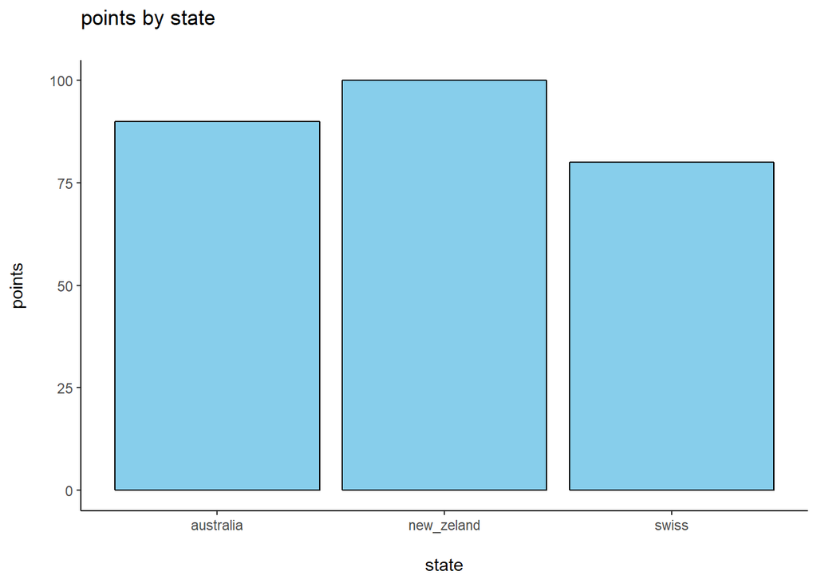

```r
#1. 데이터 생성
a <- data.frame(state=c('new_zeland','australia','swiss'), points=c(100,90,80))

#2. geom_bar()함수를 활용한 막대그래프
p <- ggplot(a, aes(x = state, y = points)) +  geom_bar(stat = "identity", color = "black", fill = "skyblue")

p + labs(title = "points by state\n",  # "\n"을 붙임으로써 그래프와의 약간의 거리를 둘 수 있다.
         x = "\nstate", y = "points\n")  + theme_classic() # 테마 형태
```

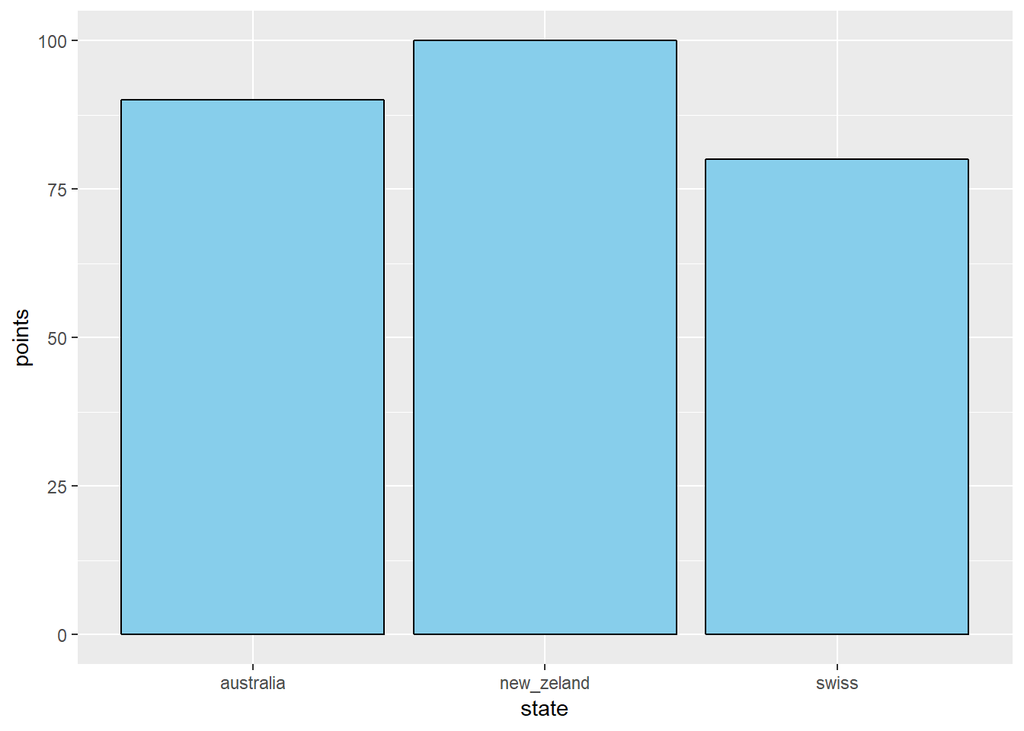

```r
  # 제목과 x,y 축 변수명 설정.
p
```

### 2.7 수직 막대그래프

- 복수 개의 계열로 이루어진 막대 차트를 사용.
- 가능하면 범주의 구조를 최대한 쉽게 만들도록 함.

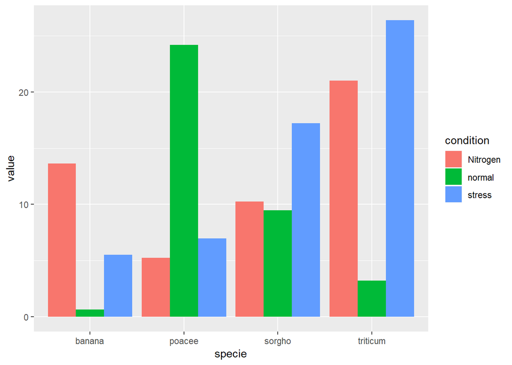

```r
#1. 데이터셋 만들기
specie=c(rep("sorgho" , 3) , rep("poacee" , 3) , rep("banana" , 3) , rep("triticum" , 3) )
condition=rep(c("normal" , "stress" , "Nitrogen") , 4)
value=abs(rnorm(12 , 0 , 15))
data=data.frame(specie,condition,value)

#2. 복수 계열 그룹별 막대차트 1
ggplot(data, aes(fill=condition, y=value, x=specie)) +
  geom_bar(position="dodge", stat="identity")
```

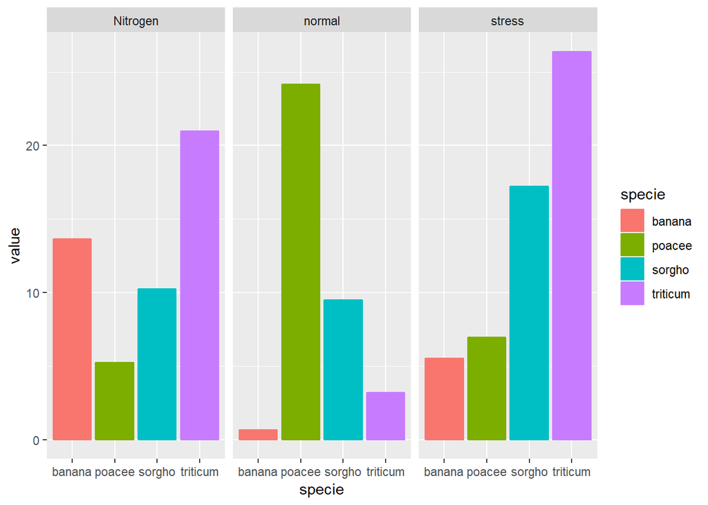

```r
#3. 복수 계열 그룹별 막대차트 2
# 범주의 개수가 많아 읽기 힘들 때 사용하면 좋다.
ggplot(data, aes(y=value, x=specie, color=specie, fill=specie)) +  # fill=값, 양적변수
  geom_bar( stat="identity") +
  facet_wrap(~condition)
```

### 2.8 누적 수직 막대그래프

- 강조하고 싶은 개별요소를 막대의 가장 말단에 두는 것이 좋다.

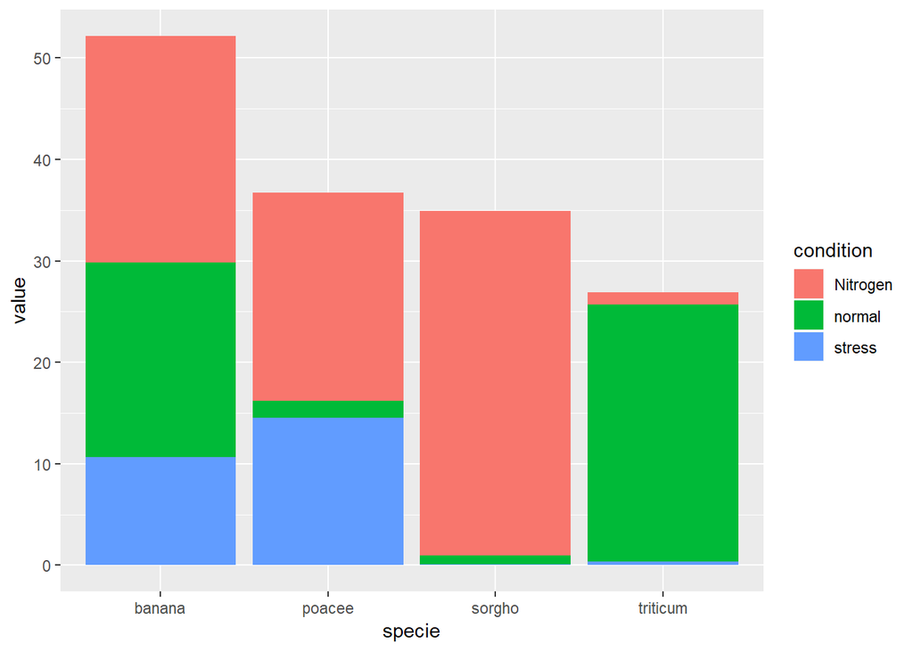

```r
#1. 데이터셋 만들기
specie=c(rep("sorgho" , 3) , rep("poacee" , 3) , rep("banana" , 3) , rep("triticum" , 3) )
condition=rep(c("normal" , "stress" , "Nitrogen") , 4)
value=abs(rnorm(12 , 0 , 15))
data=data.frame(specie,condition,value)

#2. 누적 수직 막대그래프
ggplot(data, aes(fill=condition, y=value, x=specie)) +
  geom_bar( stat="identity") # stat 의 "identity" 는 데이터 프레임 값 그대로 사용하라는 뜻이다.
```

### 2.9 수평 막대 그래프

- 범주형 데이터 중 범주가 긴 경우에 적합.
- ‘Z’ 모양 접근을 통해 보면 범주를 가장 먼저 볼 수 있다.
- 가장 큰 범주가 중요하면 내림차순으로 범주를 정렬 반대면 오름차순 정렬.

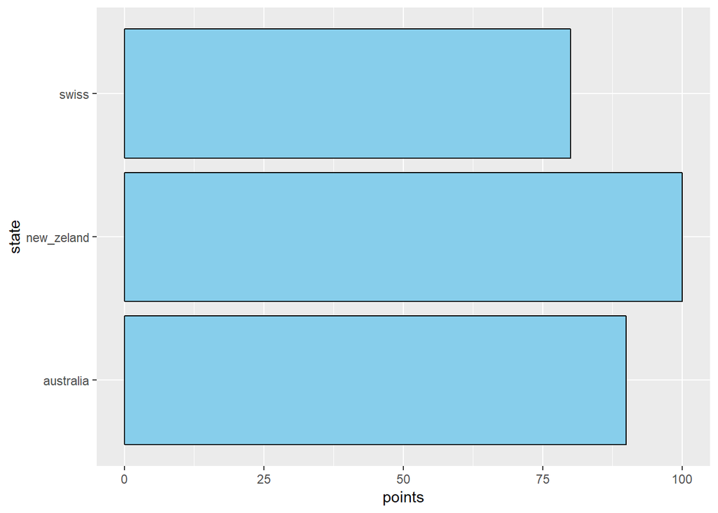

```r
#1. 데이터 생성
a <- data.frame(state=c('new_zeland','australia','swiss'), points=c(100,90,80))

#2. geom_bar() + coord_flip() 함수를 활용한 수평 막대그래프
p <- ggplot(a, aes(x = state, y = points)) +  geom_bar(stat = "identity", color = "black", fill = "skyblue") + coord_flip()
p
```

### 2.10 누적 수평 막대 그래프

-다양한 범주형에 대한 총합을 보여주거나 구성 요소별로 이해하기 위해 사용할 수 있음. - 여러 다양한 범주는 절대값이나 총합을 100%가 되게 구조화 할 수 있음.

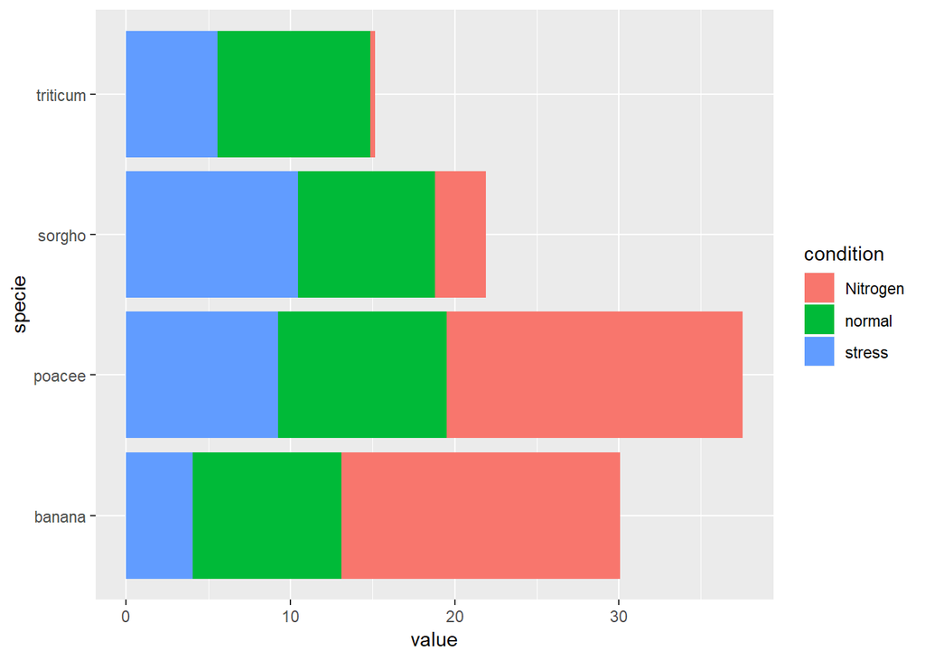

```r
#1. 데이터셋 만들기
specie=c(rep("sorgho" , 3) , rep("poacee" , 3) , rep("banana" , 3) , rep("triticum" , 3) )
condition=rep(c("normal" , "stress" , "Nitrogen") , 4)
value=abs(rnorm(12 , 0 , 15))
data=data.frame(specie,condition,value)

#2. 누적 수직 막대그래프
ggplot(data, aes(fill=condition, y=value, x=specie)) +
  geom_bar( stat="identity") + coord_flip()
```

### 2.11 폭포 그래프

- 시작점과 *증감 결과인 끝점*을 보여주기 위해 사용.

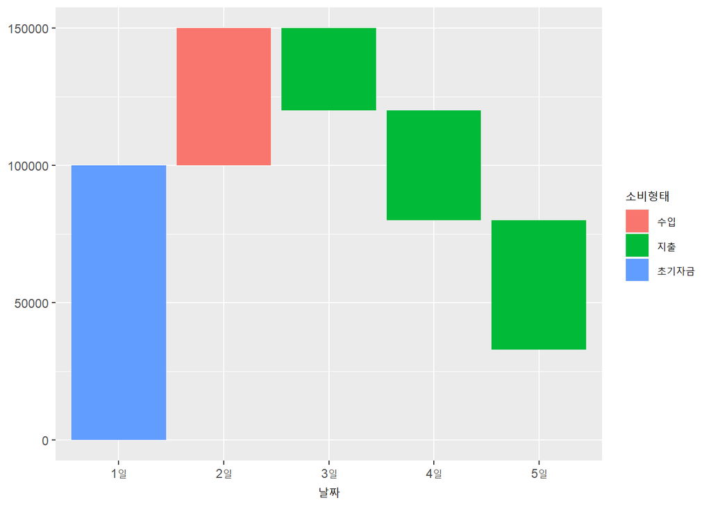

```r
#1. 데이터생성
가계부 <- data.frame(행번호=c(1,2,3,4,5),
                    날짜=c("1일","2일","3일","4일","5일"),
                    소비형태=c("초기자금",'수입','지출','지출','지출'),
                    start=c(0,100000,150000,120000,80000),
                    end=c(100000,150000,120000,80000,33000)
                    )

#2. geom_rect() 을 사용.
ggplot(가계부, aes(날짜,fill=소비형태)) + geom_rect(aes(x=날짜,xmin=행번호-0.45,xmax=행번호+0.45,ymin=end,ymax=start)) # x의 min,max. y의 min,max. 의 범위(값) 설정
```

### 2.12 사각형 영역 그래프

- 다른 그래프보다 청중이 이해하기 어려움.
- 간결한 방법으로 사각형을 이용한 이차원으로 실행한다.

** 유의사항 **

- 파이그래프는 숫자 인식을 왜곡시킬 수 있기 때문에 3D 사용을 자제. 데이터 라벨을 붙여본다. 백분율류로 환산하여 수평 막대 그래프로 변형.
- 3D를 사용하지 말자. 숫자를 왜곡하거나 비교하기 어렵거나 불가능하게 만든다.
- 또 하나의 y축을 그리게 되면 어떤 데이터를 읽어야 하는지 이해하는데 시간이 소요됨. 만약 y축을 추가한다면 데이터 포인트에 값을 직접 표시하자.

## 3. 불필요한 요소 제거하기

### 3.1 게슈탈트의 원리

** 근접성(Proximity) **

- 물리적으로 함께 있는 객체를 그룹의 일부에 속하는 것으로 인식하는 경향

**유사성(Similarity)**

- 유사 색상, 모양, 크기, 방향을 갖는 객체는 그룹의 일부에 속한다고 인식하는 경향.

**공통성(Enclosure)**

- 패쇄 도형 안의 개체가 하나의 그룹으로 보이게 하는 방법.

**완결성(Closure) = 폐쇄성의 법칙**

- 전체의 일부분이 생략되어 있더라도 생략된 부분을 채우는 경향.
- 외곽선, 테두리, 백그라운드 그림자 넣기 등의 기능이 불필요할 수 있다.

**연속성(Continuity)**

- 완결성 원리와 유사. 연속된 그림을 보며 판단해버리는..

**연결성(Connection)**

**형태/배경의 법칙** - 우리는 가까운 개체를 보려고 하고, 개 체는 단위로 보려고 한다거나, 개체는 배경에 비해 더 작게 보려고 하는 경향 이 있음.

**공동 운명의 법칙**

- 같은 방향으로 움직이는 개체들은 하나의 그룹으로 보이는 것을 말함.

**시각화에 대한 게슈탈트 법칙의 영향**

- 구분의 법칙>연결의 법칙>근접의 법칙

### 3.2 베버의 법칙: 좌표선과 기준선이 필요한 이유

### 3.3 스티븐스의 멱함수 법칙: 왜곡 인지하기

## 4. 청중의 주목 이끌기

### 4.1 기억 매커니즘

- 아이콘 메모리: 처리 과정이 매우 빠르며, 여러분이 주변 환경을 살펴볼 때, 무의식적으 로 변화나 위험을 감지.
- 단기 메모리: 주어진 시간 내 단기 메모리에 4가지 시각화 정보를 보관할 수 있음. 게슈탈트의 완결성 원리를 사용하여 시각화 자료 작성
- 장기 메모리: 단기 메모리에서 기억사항들이 사라지면 망각하거나 영원히 잃어버리게 되 거나 아닌 경우에는 장기 메모리로 이동. 패턴 인식과 일반적인 인식처리를 위해 중요한 역할을 함. 청중에게 전달하는 메시지가 장기 메모리에 저장되도록 시각과 구두 정보를 잘 결합시켜야 함

## 5. 설계자처럼 생각하기

### 5.1 정보 설계 개념_행동용이성(affordance)

-행동용이성은 제품이 사용되는 방법을 명확히 하는 설계와 관련이 있음

-행동용이성을 고려해 시각화 자료 만들기 – 중요한 것을 강조하자 – 혼란스러움을 제거하라 – 명확한 정보체계를 만들어라

### 5.2 정보 설계 개념_이해용이성(accessibility)

- 너무 복잡하게 만들지 말라

  ```
  “읽기가 힘들면, 이해하기도 어렵다”(2008년 미시간 대학의 송과 슈바르츠 연구)
  1. 가독성을 확보: 일관성 있고 쉬운 폰트 사용
  2. 깔끔함을 유지
  3. 직관적인 언어를 사용: 간결한 언어 사용. 약어보다 풀어서 쓰거나 최소한 처음 사용 시 주석을 달자
  4. 불필요한 복잡성을 제거
  ```

### 5.3 정보 설계 개념_심미학(aesthetics)

- 사람들은 아름다운 디자인을 좀 더 쉽게 받아들임
- 미적 설계를 위한 팁
1. 색상에 좀 더 스마트해져라
2. 정렬에 주의하라
3. 여백을 사용하자

### 5.4 채택

1. 새롭거나 다른 접근의 이익을 문서화한다
2. 나란히 보여준다. 신규 접근이 기존 접근보다 우수하다면 나란히 표시해 이 를 증명
3. 다양한 선택권을 제공하고 피드백을 받는다: 요청사항을 만족시키는데 최선 의 선택인지를 결정하기 위해 몇 가지 옵션을 만들고 청중이나 동료로부터 피드백을 받자
4. 이사회 청중 중에서 영향력 있는 구성원을 확보하자: 영향력 있는 멤버를 확 인하고 그들의 피드백을 받고 반영하자

참고 자료. 후마니타스 빅데이터 센터 교육 자료. https://www.r-graph-gallery.com/48-grouped-barplot-with-ggplot2/ http://www.dodomira.com/2016/03/18/ggplot2-기초/